# 국립대학 BEMS 구축 및 운영 현황

Author

한국교육시설안전원 대학시설사업단

Published

2025-08-22

# 1. 구축현황

## 1.1 구축단계 현황

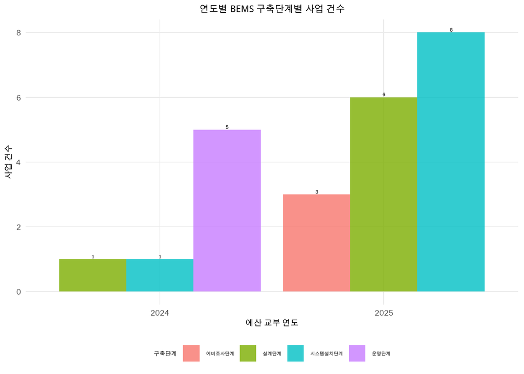

| 예산교부연도 | 구축단계_표준 | 건수 |
| --- | --- | --- |
| 2024 | 설계단계 | 1 |
| 2024 | 시스템설치단계 | 1 |
| 2024 | 운영단계 | 5 |
| 2025 | 예비조사단계 | 3 |
| 2025 | 설계단계 | 6 |
| 2025 | 시스템설치단계 | 8 |

## 1.2 건물대비 BEMS 구축률

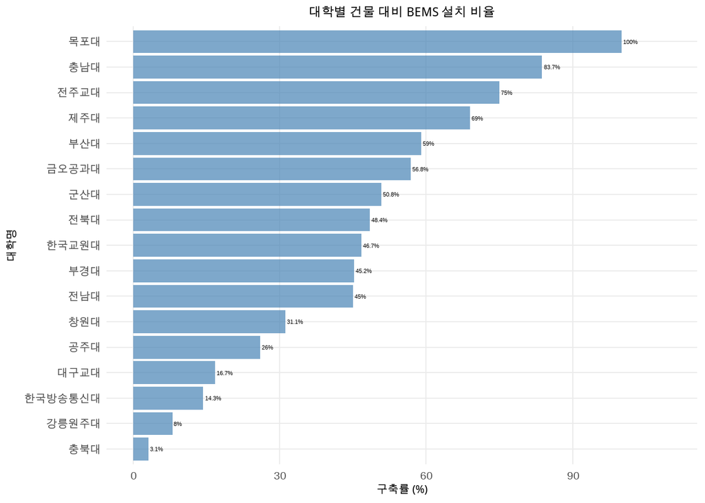

| 대학명 | 사업건수 | 평균구축률 | 총전체건물수 | 총구축건물수 |
| --- | --- | --- | --- | --- |
| 목포대 | 1 | 100.0 | 39 | 39 |
| 충남대 | 1 | 83.7 | 86 | 72 |
| 전주교대 | 1 | 75.0 | 16 | 12 |
| 제주대 | 2 | 69.0 | 174 | 120 |
| 부산대 | 2 | 59.0 | 320 | 189 |
| 금오공과대 | 2 | 56.8 | 88 | 50 |
| 군산대 | 2 | 50.8 | 61 | 31 |
| 전북대 | 1 | 48.4 | 159 | 77 |
| 한국교원대 | 1 | 46.7 | 60 | 28 |
| 부경대 | 2 | 45.2 | 186 | 84 |
| 전남대 | 1 | 45.0 | 180 | 81 |
| 창원대 | 2 | 31.1 | 106 | 33 |
| 공주대 | 1 | 26.0 | 73 | 19 |
| 대구교대 | 2 | 16.7 | 30 | 5 |
| 한국방송통신대 | 1 | 14.3 | 42 | 6 |
| 강릉원주대 | 1 | 8.0 | 25 | 2 |
| 충북대 | 1 | 3.1 | 65 | 2 |

# 2. 운영현황

## 2.1 에너지원별 계측 현황

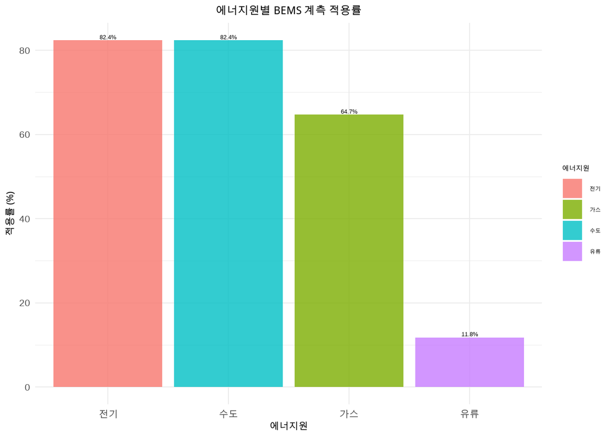

| 에너지원 | 적용여부 | count | total | percentage |
| --- | --- | --- | --- | --- |
| 전기 | 적용 | 14 | 17 | 82.35294 |
| 가스 | 적용 | 11 | 17 | 64.70588 |
| 수도 | 적용 | 14 | 17 | 82.35294 |
| 유류 | 적용 | 2 | 17 | 11.76471 |

## 2.2 용도별 계측 현황

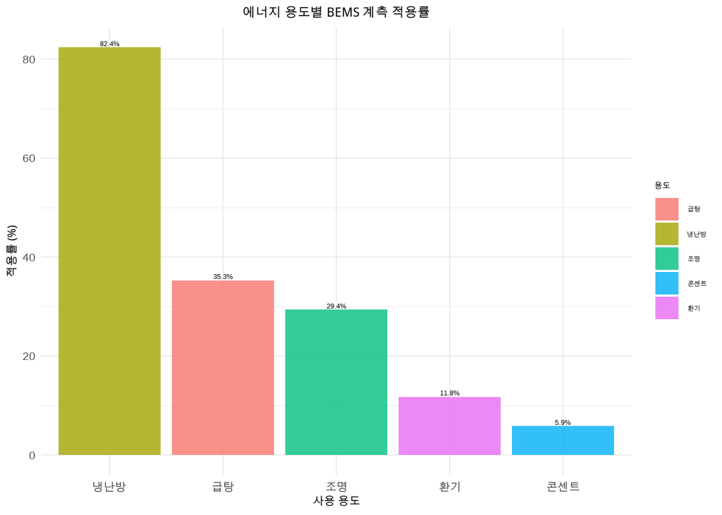

| 용도 | 적용여부 | count | total | percentage |
| --- | --- | --- | --- | --- |
| 급탕 | 적용 | 6 | 17 | 35.294118 |
| 냉난방 | 적용 | 14 | 17 | 82.352941 |
| 조명 | 적용 | 5 | 17 | 29.411765 |
| 콘센트 | 적용 | 1 | 17 | 5.882353 |
| 환기 | 적용 | 2 | 17 | 11.764706 |

## 2.3 관제실 운영 및 관리인력 현황

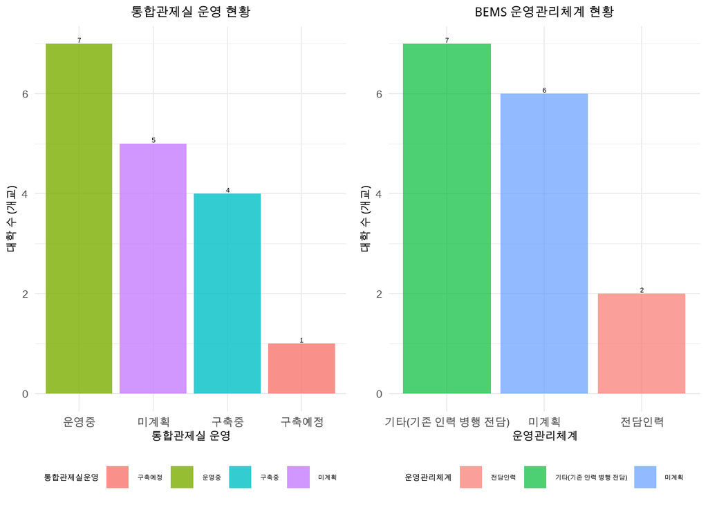

| 통합관제실운영 | n |
| --- | --- |
| 구축예정 | 1 |
| 운영중 | 7 |
| 구축중 | 4 |
| 미계획 | 5 |

| 운영관리체계 | n |
| --- | --- |
| 전담인력 | 2 |
| 기타(기존 인력 병행 전담) | 7 |
| 미계획 | 6 |

## 2.4 BEMS 성과지표 현황

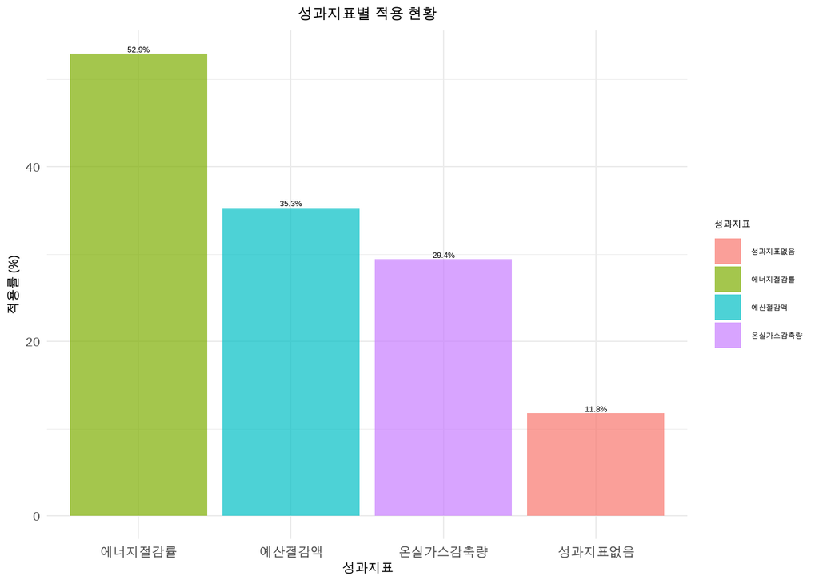

| 성과지표 | 적용여부 | count | total | percentage |
| --- | --- | --- | --- | --- |
| 성과지표없음 | 적용 | 2 | 17 | 11.76471 |
| 에너지절감률 | 적용 | 9 | 17 | 52.94118 |
| 예산절감액 | 적용 | 6 | 17 | 35.29412 |
| 온실가스감축량 | 적용 | 5 | 17 | 29.41176 |

# 3. 애로사항

## 3.1 기술적‧물리적 제약

**1) 노후 건물의 구조적 한계**

- 기존 건물의 전력선로 미분리 및 회로 파악의 어려움으로 인해 에너지 측정 데이터의 신뢰도 저하 및 오차 발생
- 건물 구조물 및 마감재의 특성상 일부 구간에 센서 및 계측장비의 물리적 부착이 곤란하여 데이터 수집 범위에 제약

**2) 시스템 상호 연계 및 표준화 미흡**

- 타 시스템 간 통신 프로토콜의 불일치로 데이터 연계 및 호환성 확보에 어려움
- 기존 설비와의 연계를 위한 기술 표준 부재로 시스템 통합 및 확장의 효율성 저해

**3) 에너지 사용량 세부 계측의 어려움**

- 건물의 실별, 층별, 용도별(예: 조명, 전열) 에너지 사용량을 분리 계측하기 위한 인프라가 미비하며, 관련 공사 추진 시 과다한 비용 소요
- 캠퍼스 및 학과별로 상이한 에너지 소비 패턴으로 인해 BEMS의 최적 구역 설정 및 효율적 운영방식 선정의 복잡성 증대

## 3.2 행‧재정적 지원체계 미흡

**1) 재정 지원의 한계**

- 초기 구축 사업비 부족으로 BEMS 인증 기준 충족 및 핵심 기능(예: 냉‧난방 제어) 구현이 어려워 시스템의 완성도 및 성능 저하 우려
- 하자보수 기간 만료 이후, 시스템의 안정적 운영 및 고도화에 필수적인 유지보수‧관리 재원 확보 방안 부재

**2) 사업관리의 경직성 및 비효율성**

- 단년도 예산 배정 원칙으로 인해 중장기적 관점의 사업 추진이 곤란하며, 사업 범위가 당해 예산에 따라 유동적으로 조정되는 문제 발생

※ 다년도에 걸쳐 사업 추진 시, 연차별 사업자가 상이할 경우 하자 책임 소재의 불명확성 문제 야기

- 사업 추진에 대한 학내 구성원의 수용성 및 협조가 미흡하여 현장 호응도가 저하되는 등 정책 추진 동력 확보가 어려움

## 3.3 전문 운영인력 인프라 취약

**1) 전담 인력 및 조직 부재**

- BEMS의 지속가능하고 안정적인 운영을 위한 전담 인력 또는 조직이 부재하여 장기적 운영 안정성 확보가 곤란

※ 기존 시설관리 인력만으로는 전문적인 시스템 유지보수 및 데이터 기반의 에너지 관리 수행에 한계

**2) 전문성 제고를 위한 지원 시스템 전무**

- 기존 인력의 BEMS 운영 역량 제고를 위한 체계적‧주기적 교육 프로그램이 전무하여 전문성 강화에 한계

# 4. 건의사항

## 4.1 기술 표준화 및 인프라 고도화

**1) BEMS 구축‧운영 가이드라인 제공**

- 시스템 상호운용성 확보를 위한 기술 표준 및 데이터 프로토콜을 명확히 정의하고, 사업 범위 및 기술 기준에 대한 구체적 가이드라인 제시 필요
- 기존 건물의 BEMS 구축은 인증 목적보다 실제 에너지 사용량 분석 및 효율 개선에 중점을 두도록 정책 방향 설정

**2) 데이터 기반 거버넌스 구축**

- 유관기관(예: 한국지역난방공사)이 보유한 에너지 데이터의 공유 및 활용을 위한 협력체계 구축

## 4.2 지속가능한 행‧재정적 지원체계 확립

**1) 국고 지원의 연속성‧안정성 확보**

- 하자보수 기간 만료 이후에도 시스템이 안정적으로 운영될 수 있도록 유지관리비를 국고에서 연속적으로 지원하는 방안 고려
- 기술 발전에 따른 시스템의 주기적(예: 3년 단위) 성능 개선 및 업그레이드를 위한 예산의 안정적 편성‧지원

**2) 사업 예산 책정의 합리성 제고**

- BEMS 구축의 핵심 기능 구현 및 실질적 에너지 절감 목표 달성을 위해, 기 추진 사례 분석을 바탕으로 사업비를 현실화하고 증액 검토
- 신축 건물에 대한 BEMS 적용을 의무화하고, 관련 사업비를 건축 예산에 안정적으로 반영하는 정책 추진

**3) 정책 추진 기반 강화**

- 사업의 원활한 대학 내 안착을 위해 상위 기관(예: 교육부)의 공식적인 행정 지원(예: 협조 공문)을 통해 정책 추진 동력 확보

※ BEMS는 초기 절감효과는 제한적이나 에너지 관리 인프라 구축과 탄소중립 기조 확산을 위한 장기적 지원 필요

## 4.3 전문인력 양성 및 조직 역량 제고

**1) 운영인력 확충을 위한 제도적 기반 조성**

- BEMS 운영 전담 인력의 필요성을 인정하고, 각 대학의 정원(T/O)에 이를 의무적으로 반영하는 등 제도적 개선 필요

**2) 운영인력 전문성 강화 교육 프로그램 도입**

- 운영 인력의 전문성 및 역량 제고를 위해 주기적‧체계적인 전문 교육 프로그램을 도입하고, 관련 예산 지원